# Part I Explore

# 3.5 Facets

*subplots that each display one subset of the data*

The first argument of facet_wrap() should be a formula, which you create with ~ followed by a variable name (here “formula” is the name of a data structure in R, not a synonym for “equation”). The variable that you pass to facet_wrap() should be discrete.

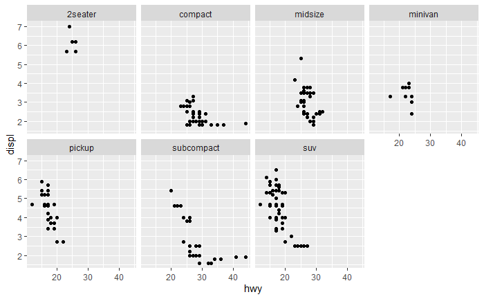

```r
ggplot(data = mpg, aes(x = hwy, y = displ)) + geom_point() + facet_wrap(~ class, nrow = 2)
```

To facet your plot on the combination of two variables, add facet_grid() to your plot call. The first argument of facet_grid() is also a formula. This time the formula should contain two variable names separated by a ~.

If you prefer to not facet in the rows or columns dimension, use a . instead of a variable name, e.g. + facet_grid(. ~ cyl).

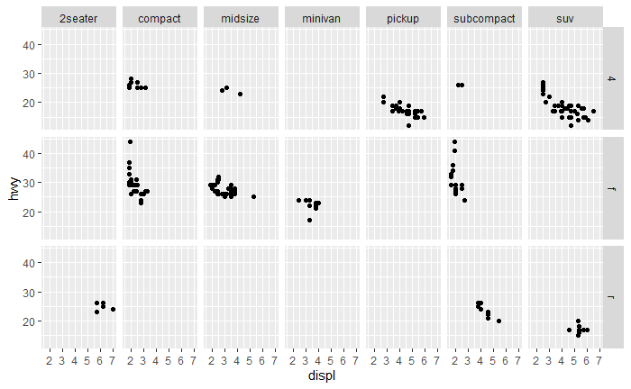

```r
ggplot(data = mpg) + geom_point(mapping = aes(x = displ, y = hwy)) + facet_grid(drv~ class)
```

**3.6 Geometric objects**

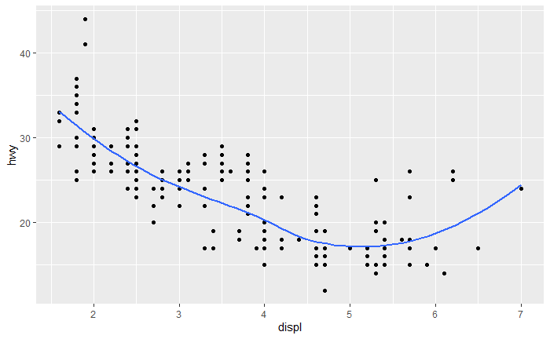

```r
ggplot(data = mpg, aes(x = displ, y = hwy)) + geom_point() + geom_smooth(se = FALSE)
```

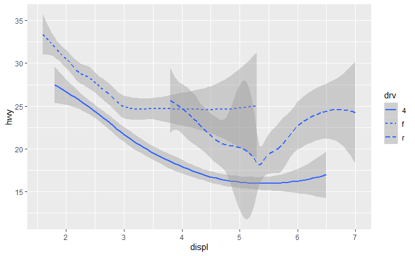

```r
ggplot(data = mpg, aes(x = displ, y = hwy, linetype = drv)) + geom_smooth()
```

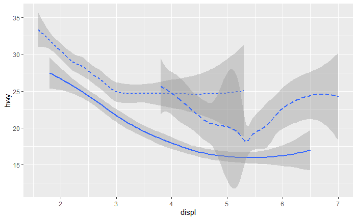

```r
ggplot(data = mpg, aes(x = displ, y = hwy, linetype = drv)) + geom_smooth(show.legend = FALSE)
```

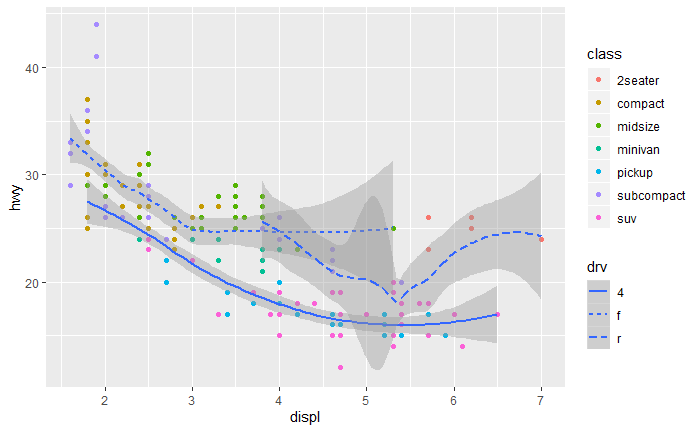

```r
ggplot(data = mpg, aes(x = displ, y = hwy, linetype = drv)) + geom_point(aes(color = class)) + geom_smooth()
```

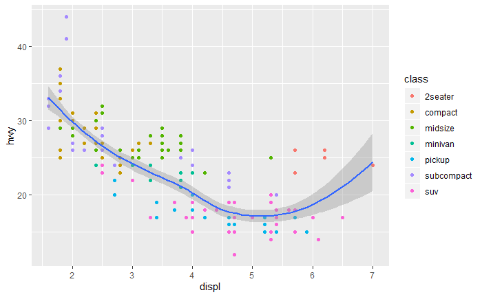

```r
ggplot(data = mpg, aes(x = displ, y = hwy)) + geom_point(aes(color = class)) + geom_smooth()
```

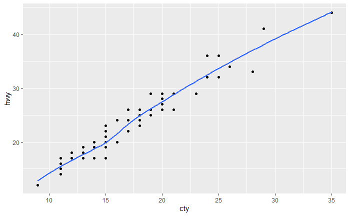

```r
ggplot(data = mpg, aes(x = cty, y = hwy)) + geom_point(data = filter(mpg, class == "subcompact" | class == "suv")) + geom_smooth(data = filter(mpg, class == "subcompact" | class == "suv"), se = FALSE)
```

```r
NA
```

# 3.7 Statistical transformations

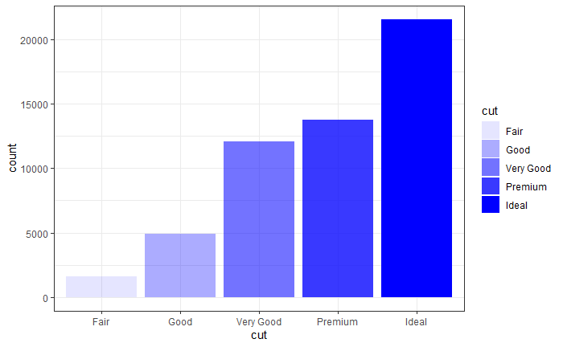

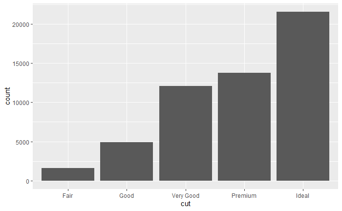

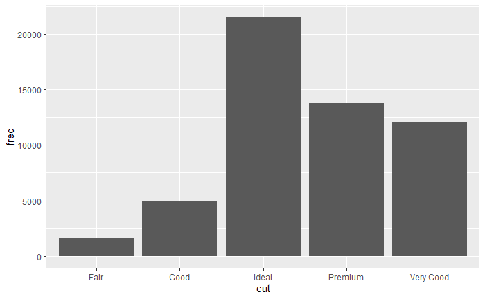

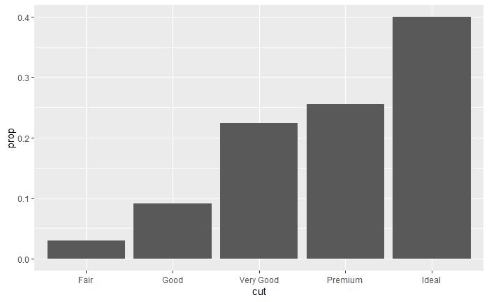


# 3.8 Position adjustments

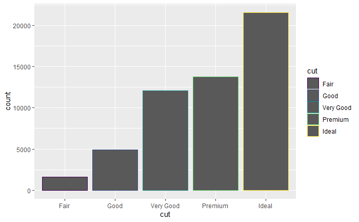

```r
ggplot(data = diamonds) +
  geom_bar(mapping = aes(x = cut, colour = cut))
```

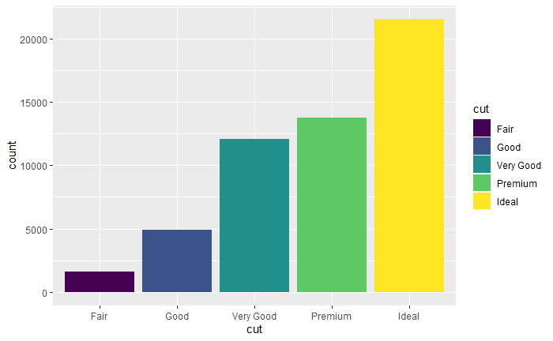

```r
ggplot(data = diamonds) +
  geom_bar(mapping = aes(x = cut, fill = cut))
```

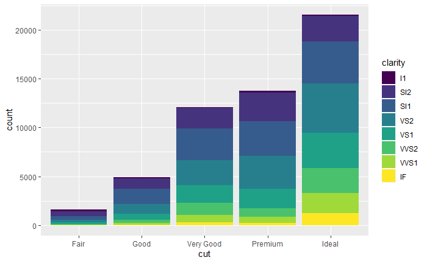

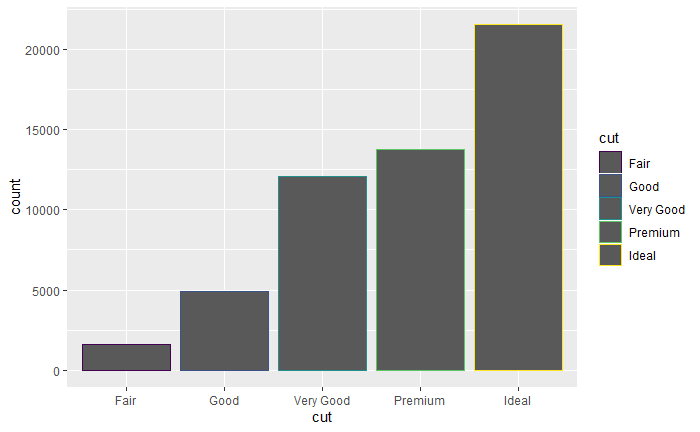

```r
ggplot(data = diamonds) +
  geom_bar(mapping = aes(x = cut, colour = cut))
```

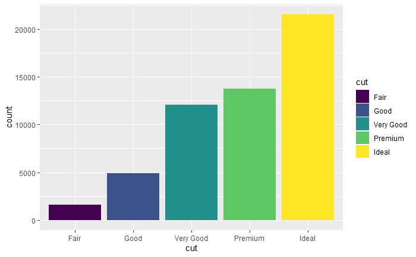

```r
ggplot(data = diamonds) +
  geom_bar(mapping = aes(x = cut, fill = cut))
```

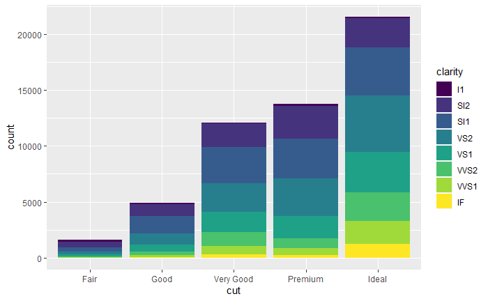

```r
ggplot(data = diamonds) +
  geom_bar(mapping = aes(x = cut, fill = clarity))
```

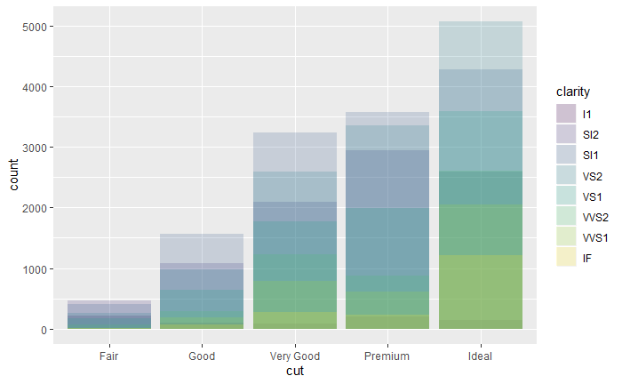

```r
ggplot(data = diamonds, mapping = aes(x = cut, fill = clarity)) +
  geom_bar(alpha = 1/5, position = "identity")
```

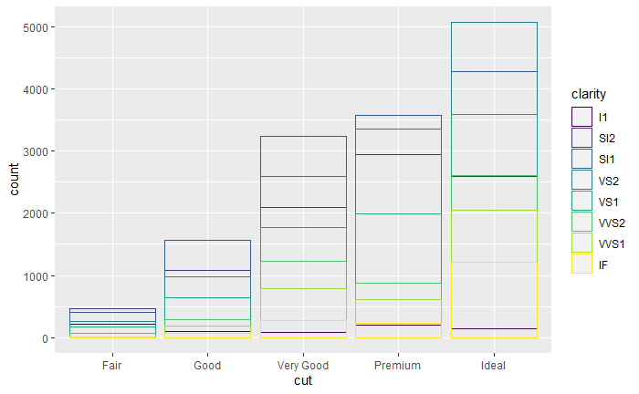

```r
ggplot(data = diamonds, mapping = aes(x = cut, colour = clarity)) +
  geom_bar(fill = NA, position = "identity")
```

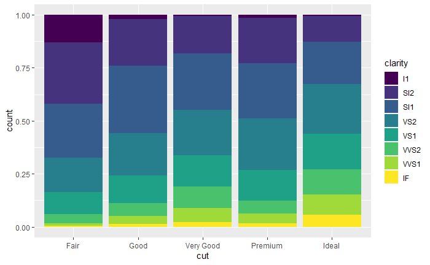

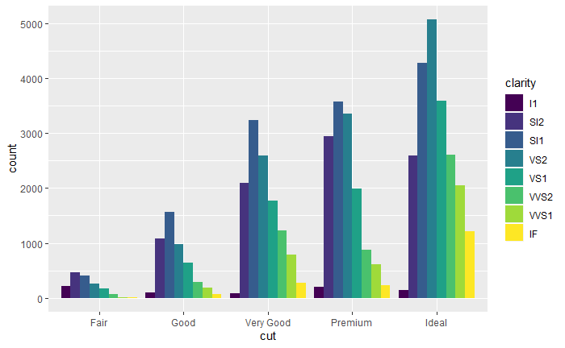

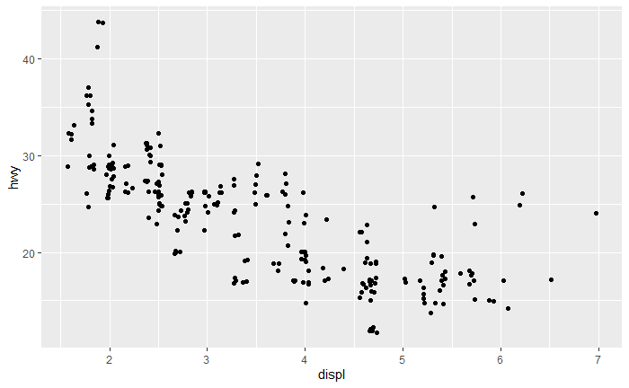